# Welcome to BIS180L

Julin Maloof  
April 02, 2019

### Course Personnel

**Instructor:** Julin Maloof jnmaloof@ucdavis.edu

**Teaching Assistant:** John Davis jtdavis@ucdavis.edu

**Extra Help (today):** Jiadong Ni

### What this course is about

The goal of this course is to introduce you to the *tools* and *thinking* required for bioinformatics analysis.

This is a computer-based class. No bench work.

### Learning Objectives

At the end of this course you should be able to:

- Use cloud computing resources like AWS
- Navigate the Linux operating system at the command line for file management and invocation of bioinformatics programs
- Automate repetitive computational tasks using loops
- Write scripts in R for data analysis and display
- Perform genome wide association studies (GWAS)
- Analyze Illumina sequencing data to find sequence polymorphisms

### Learning Objectives, Continued

- Analyze RNA-seq data to find differentially expressed genes and pathways
- Make and deploy Shiny web applications
- Reconstruct genetic co-expression networks
- Analyze metagenomics data
- Apply best practices for reproducible data analyses via git version control and markdown notebooks

### Most interested in? Most unfamiliar with?

- Cloud computing / AWS
- Linux command line
- Automate tasks using loops
- Write scripts in R for data analysis and display
- Perform genome wide association studies (GWAS)
- Analyze Illumina sequencing data to find sequence polymorphisms
- Analyze RNA-seq data / differentially expressed genes and pathways
- Shiny web applications
- Genetic co-expression networks
- Metagenomics data
- Reproducible data analyses / git / markdown

### Why R and Linux?

- Both R and Linux have command-line interfaces
- Antiquated?
- NO! Written code provides **flexibility, creativity, and power** not available in any other way
- Linux (or Unix / Mac)
  - Outstanding built-in tools for data crunching
  - Provides access to hundreds of bioinformatics programs
  - Easy to automate repetitive tasks

### Why R and Linux?

- R
  - Powerful scripting, statistical, data processing, and graphical capabilities
  - Many bioinformatics packages are developed in R
  - Easy to automate repetitive tasks.

### And

[coding is cool](http://www.huffingtonpost.com/2013/02/27/code-org-video_n_2767453.html)

“Every student deserves the opportunity to learn computer programming. Coding can unlock creativity and open doors for an entire generation of American students. We need more coders — not just in the tech industry, but in every industry.” – Mark Pincus, CEO and Founder, Zynga

“Coding is engaging and empowering. It’s a necessary 21st Century skill.” – Jan Cuny, Program Officer, National Science Foundation

### And

[coding is cool](http://www.huffingtonpost.com/2013/02/27/code-org-video_n_2767453.html)

“Code has become the 4th literacy. Everyone needs to know how our digital world works, not just engineers.” – Mark Surman, Executive Director, The Mozilla Foundation

“If you can program a computer, you can achieve your dreams. A computer doesn’t care about your family background, your gender, just that you know how to code. But we’re only teaching it in a small handful of schools, why?” – Dick Costolo, CEO, Twitter

### Do you want to succeed in this class?

Secrets for success:

1. You are learning a new language, treat it as such.
2. Go slow. If your goal is to get out of this room as soon as possible you will not succeed.
3. Read the lab instructions carefully. See #2.
4. Do not cut and paste code. Type it; you will learn it better.
5. Take the time to understand a command. THINK!
6. Do ask for help when you are stuck or confused.
7. Google is a good resource for coding questions.
8. Be kind to yourself and your community.

### Course Schedule

- **Tuesdays, Thursdays**
  - Lecture 1:10 - 2:00
  - Lab 2:10 - 5:00
  - Often lecture will be shorter than 1 hour. We will start lab work as soon as lecture is over.
- **Fridays**
  - Discussion 1:10 - 2:00
  - Varied use
    - Q & A (with student helping to A as well as Q)
    - lecture
    - Keep on working

### (Tentative) Course Outline

- Week 1-2:
  - Linux fundamentals
  - Markdown, git repositories
  - Sequence analysis and BLAST
- Week 3:
  - R fundamentals
- Week 4:
  - SNPs
  - population structure, GWAS
- Week 5:
  - Build a web-app
- Weeks 6-7:
  - Illumina reads
  - RNAseq
- Week 8:
  - Genetic Networks
- Week 9:
  - Metagenomics
- Week 10
  - TBD

### Course Grading

- 45% Lab assignments
- 25% Take home midterm (Available May 4, **Due May 09, 1:10 PM**)
- 25% Take home final (Available June 5, **Due June 10, 9:00 AM**)
- 5% Discussion/participation (TBD)

### Do your own work

Developing code is an interactive process. Both your friends and the web can be excellent resources.

**However** Any direct copying of text or code **from any source** is considered plagiarism in the context of this course.

If you receive inspiration or ideas from an external source **give attribution**

### Course Website

- Main website: http://jnmaloof.github.io/BIS180L_web/
  - Lab instructions
  - Course Schedule
  - Helpful Links (to be updated as we go)
  - Reading assignments (to be updated as we go)
- Canvas
  - Gradebook

### Reference Text

[figure not shown]

This is an excellent book that covers much of the material that is covered in lab.

You can use this to help with ideas that are not clear from class, or for more in depth coverage of the material.

I particularly recommend reading it in depth for anyone planning to build on the skills learned in this class.

It is available online for free, through UCD library. See links on course website.

### Reference Text2

[figure not shown]

This is another excellent book that more generally covers data manipulation and analysis in R.

The author, Hadley Wickham, has built some very nice additions to R that we will make use of in this class.

### Bioinformatics best practices

1. Clear documentation
2. Reproducible results
3. Documents/Data in open (non-proprietary) formats
   - This is essential for achieving 1 and 2

## Today's Lab

1. **Get a virtual linux machine running**
2. Learn a little markdown
3. Learn a little Linux command line

### Virtual Linux machine

- The computer lab machines run Windows
- Bioinformatics on a Windows machine is painful (although getting better) (R is fine)
- Solution: virtual machine!
- Use [Amazon Web Services](https://aws.amazon.com/) to run a virtual Linux machine in the cloud
- You can connect to your virtual machine from any computer, including your laptop or home computer

### What is a virtual machine?

- Amazon has many very large computers (a.k.a. servers) in various places around the country
- These servers can be split up to be many separate “virtual” machines, each emulating an individual computer
- You can connect to these virtual machines and it just like having your own computer, but it is in the “cloud”
- Terminology:
  - Each virtual machine is an **instance** of a machine **image**.
  - You can think of the image as a snapshot of a machine that captures the OS, the installed programs, etc.
  - The image that you are using is called BIS180L and was created by John Davis and myself for this class.

### Connecting to the virtual machine

- There are two ways to connect to your instance:
1. Using a Virtual Network Connection (VNC). This allows the graphical display of the instance to be displayed on your local computer
2. Using a secure shell (SSH). This provides a text connection to your instance. An advantage for slow internet connections.

### Other virtual machine notes

As detailed in the lab notes for today:

- You will need to register at AWS Educate; see email from AWS educate.
- As a participant in this class $50 credit. That should easily be enough to complete this class 1500 hours of compute time) **If you stop your machine when not in use**
- Optionally you can also sign up for an AWS account, in which case you will get an additional $100 per year so long as you are at UC Davis. This option requires that you give AWS a credit card.
- **It is very important that you stop your machine when not in use**
- If you are already running Linux, or want to try installing the relevant software on your Mac, I can give you installation notes. (But for today's class please connect to AWS).

## Today's Lab

1. Get a virtual Linux machine running
2. **Learn a little markdown**
3. Learn a little Linux command line

### Markdown

Markdown is a text-based formatting system for quickly and easily generating nicely formatted output.

This presentation as well as the entire BIS180L website was written in markdown.

It helps achieve all three guiding principles:

1. Clear documentations
2. Reproducibility
3. Open formats

### Markdown vs docx

What is we want to produce this:

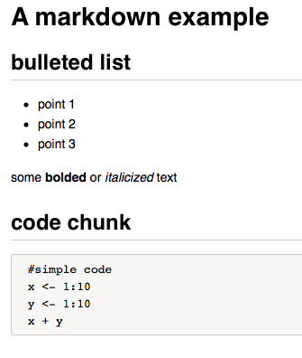

The markdown file that generates it is

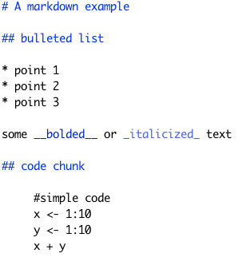

### Markdown vs docx

What is we want to produce this:

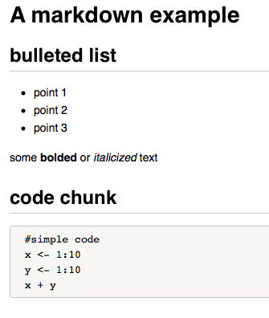

The word file that generates it is

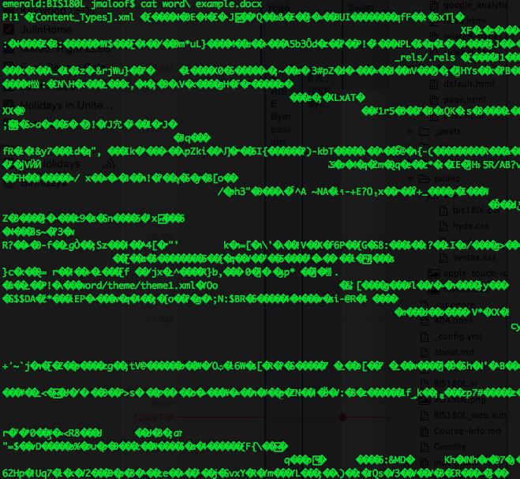

## Today's Lab

1. Get a virtual Linux machine running
2. Learn a little markdown
3. **Learn a little Linux command line**

### Linux Command Line

We will work through a tutorial developed by Ian Korf.

You are learning a new language; treat it as such.

- Keep notes
- Be patient
- Practice and repetition help
- It will get easier

### Assignments to turn in for this lab

We will provide a system for turning in assignments later this week or next week.

In the meantime, keep:

- The file from the markdown tutorial
- The notes (in Markdown!) from the Linux tutorial
- The answer to “Exercise 1” from the Linux tutorial

### Refresher: Secrets for success

### If you don't have this email, see me:

(For most of you this would have arrived in early March)

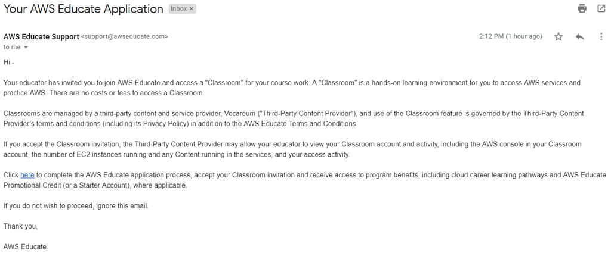